# R Lab Test - Thomaskutty_20122011

# Importing Libraries

```r
# importing libraries
library(Amelia)   # missing value plotting
library(ggplot2)  # visualization
library(caTools)  # for train test split
library(rpart.plot) # decision tree plotting
library(rpart)  # decision tree models
library(caret) # for confusion matrix
library(corrplot)  # for plotting the correlation
library(pROC) # to build the roc curve
library(e1071) # dependency for printing confusion matrix
```

# Loading the dataset

```r
df = read.csv('/home/thomaskutty/Gitrepo/Machine-Learning-with-R/data_fold/exam_data.csv')
head(df)
```

```
  V1 V2 V3 V4 V5 V6 V7 V8 V9      V10
1  x  x  x  x  o  o  x  o  o positive
2  x  x  x  x  o  o  o  x  o positive
3  x  x  x  x  o  o  o  o  x positive
4  x  x  x  x  o  o  o  b  b positive
5  x  x  x  x  o  o  b  o  b positive
6  x  x  x  x  o  o  b  b  o positive
```

# Getting the summary of dataset

```r
# getting the summary (summary(df))
summary(df)
```

```
      V1                 V2                 V3                 V4                 V5                 V6                 V7
 Length:958         Length:958         Length:958         Length:958         Length:958         Length:958         Length:958
 Class :character   Class :character   Class :character   Class :character   Class :character   Class :character   Class :character
 Mode  :character   Mode  :character   Mode  :character   Mode  :character   Mode  :character   Mode  :character   Mode  :character
      V8                 V9                V10
 Length:958         Length:958         Length:958
 Class :character   Class :character   Class :character
 Mode  :character   Mode  :character   Mode  :character
```

# Getting the summary of the data

```r
# structure of the data set (using str(df))
str(df)
```

```
'data.frame':   958 obs. of  10 variables:
 $ V1 : chr  "x" "x" "x" "x" ...
 $ V2 : chr  "x" "x" "x" "x" ...
 $ V3 : chr  "x" "x" "x" "x" ...
 $ V4 : chr  "x" "x" "x" "x" ...
 $ V5 : chr  "o" "o" "o" "o" ...
 $ V6 : chr  "o" "o" "o" "o" ...
 $ V7 : chr  "x" "o" "o" "o" ...
 $ V8 : chr  "o" "x" "o" "b" ...
 $ V9 : chr  "o" "o" "x" "b" ...
 $ V10: chr  "positive" "positive" "positive" "positive" ...
```

# Checking the missing values

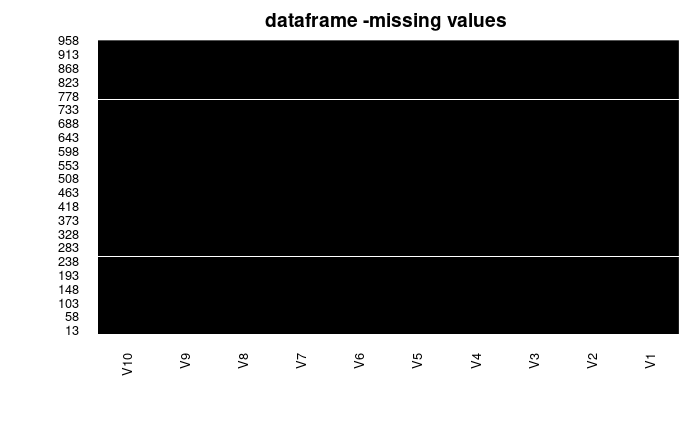

```r
# missing values
library(Amelia)
missmap(df,main = 'dataframe -missing values ', col = c("yellow", 'black'), legend = FALSE)
```

```r
# Finding the total number of missing values in each of the columns
colSums(is.na(df))
```

```
 V1  V2  V3  V4  V5  V6  V7  V8  V9 V10
  0   0   0   0   0   0   0   0   0   0
```

# Attaching the dataframe

```r
attach(df)
```

# Splitting the data into train and test

```r
# splitting the data
set.seed(100)
sample = sample.split(df$V10, SplitRatio = 0.7)
df.train = subset(df, sample == TRUE)
df.test = subset(df, sample == FALSE)
```

# Printing the dimensions of the train and test

```r
dim(df.train)
```

```
[1] 670  10
```

```r
dim(df.test)
```

```
[1] 288  10
```

# Visualization

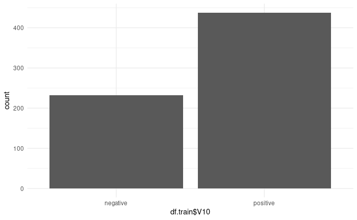

```r
ggplot(data = df.train, aes(df.train$V10)) + geom_bar(aes ())+ theme_minimal()
```

we can see that data set is not balanced.

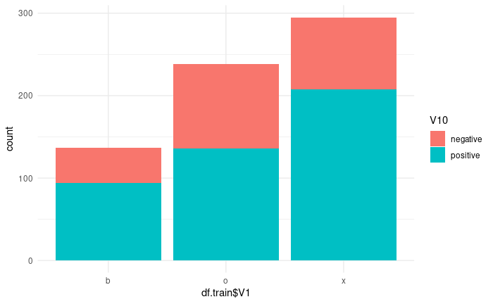

```r
ggplot(data = df.train, aes(df.train$V1)) + geom_bar(aes(fill = V10))+ theme_minimal()
```

Interpretation : we can see that each of the target has both negative and positive targets. Also above 50 % of each of the feature values got positive targets.

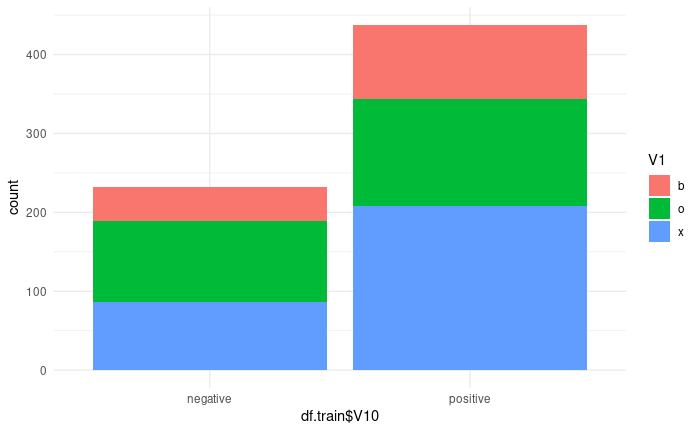

```r
ggplot(data = df.train, aes(df.train$V10)) + geom_bar(aes(fill = V1)) + theme_minimal()
```

We see that the target feature is distributed balanced with the feature V1.

# Analysing the negative target data points

```r
negative_targets = subset(df.train, df.train$V10 == "negative")
head(negative_targets)
```

```
    V1 V2 V3 V4 V5 V6 V7 V8 V9      V10
627  x  x  o  x  x  o  o  b  o negative
629  x  x  o  x  x  b  o  o  o negative
630  x  x  o  x  o  x  o  o  b negative
631  x  x  o  x  o  x  o  b  o negative
632  x  x  o  x  o  o  o  x  b negative
633  x  x  o  x  o  o  o  b  x negative
```

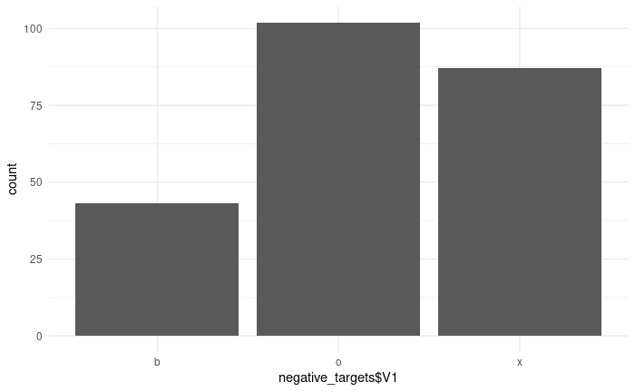

```r
ggplot(data = negative_targets, aes(negative_targets$V1))+ geom_bar()+ theme_minimal()
```

Interpretation : We see that among negative targets data most of them are v1 - 0 ::

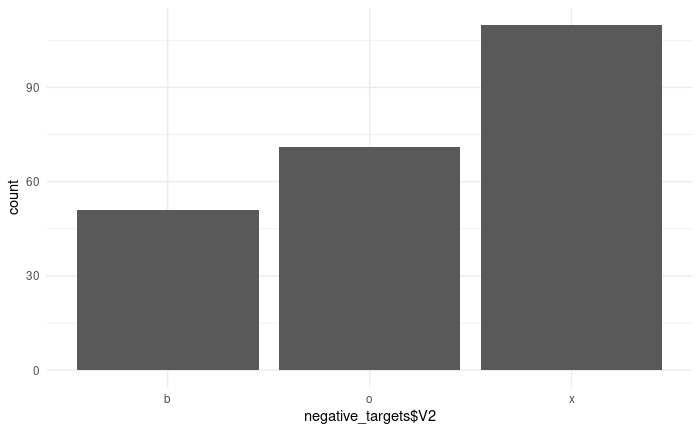

```r
ggplot(data = negative_targets, aes(negative_targets$V2))+ geom_bar() + theme_minimal()
```

But feature v2 - x got higher negative targets. ( high count of loosing for x )

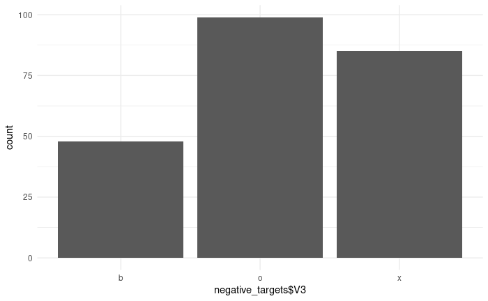

```r
ggplot(data = negative_targets, aes(negative_targets$V3))+ geom_bar() + theme_minimal()
```

feature v3 - 0 got higher negative targets.

```r
table(V2)
```

```
V2
  b   o   x
250 330 378
```

So, the the count of three labels in V2 feature is almost normal. # Model Building

```r
# model building
library(rpart)
tree = rpart(V10 ~. , method = 'class', data = df.train)
```

# Predictions from test data

```r
tree.preds  = predict(tree, df.test)
head(tree.preds)
```

```
    negative  positive
7  0.0000000 1.0000000
12 0.0000000 1.0000000
15 0.0000000 1.0000000
22 0.8235294 0.1764706
24 0.0000000 1.0000000
27 0.0000000 1.0000000
```

Note: Now we create two probability columns where the first column shows the probability of the V10 - negative, and the second column shows the probability of the v10 - positive.

```r
tree.preds = as.data.frame(tree.preds)
to_result = function(x){
  if(x <= 0.5){
    'negative'
  }else{
    'positive'
  }
}
tree.preds$final_class = sapply(tree.preds$positive, to_result)
head(tree.preds)
```

```
    negative  positive final_class
7  0.0000000 1.0000000    positive
12 0.0000000 1.0000000    positive
15 0.0000000 1.0000000    positive
22 0.8235294 0.1764706    negative
24 0.0000000 1.0000000    positive
27 0.0000000 1.0000000    positive
```

classification rule : if the probability of tree.preds$positive is greater than 0.5 then the result should be positve otherwise negative.

Lets print the head of the test data

```r
head(df.test)
```

```
   V1 V2 V3 V4 V5 V6 V7 V8 V9      V10
7   x  x  x  x  o  b  o  o  b positive
12  x  x  x  x  b  o  b  o  o positive
15  x  x  x  o  x  o  o  o  x positive
22  x  x  x  o  o  x  x  o  o positive
24  x  x  x  o  o  x  o  o  x positive
27  x  x  x  o  o  x  b  b  o positive
```

```r
cf = table(tree.preds$final_class, df.test$V10)
confusionMatrix(cf)
```

```
Confusion Matrix and Statistics


           negative positive
  negative       80       11
  positive       20      177

               Accuracy : 0.8924
                 95% CI : (0.8507, 0.9257)
    No Information Rate : 0.6528
    P-Value [Acc > NIR] : <2e-16

                  Kappa : 0.7574

 Mcnemar's Test P-Value : 0.1508

            Sensitivity : 0.8000
            Specificity : 0.9415
         Pos Pred Value : 0.8791
         Neg Pred Value : 0.8985
             Prevalence : 0.3472
         Detection Rate : 0.2778
   Detection Prevalence : 0.3160
      Balanced Accuracy : 0.8707

       'Positive' Class : negative
```

from the confusion matrix we see that 80 true negatives, and 177 true positives . Sensitivity is 0.80 and specificity is 94. Sensitivity is the true positives rate and specificity is the true negative rate.

NOte: confidence interval is a range of values er are fairly sure our true value lies in. NO information rate is just the largest class percentage in the data. cohen kappa is a type of classification evaluation metric. accuracy is the percentage of correctly classified instances out of all instances. It is more useful on a binary classification than multiclass classification problems because it can be less clear exactly hoe the accuracy breaks down across the classes. sensitivity if the ability of a test to correctly identify those that are not high and specificity is the true negative rate.

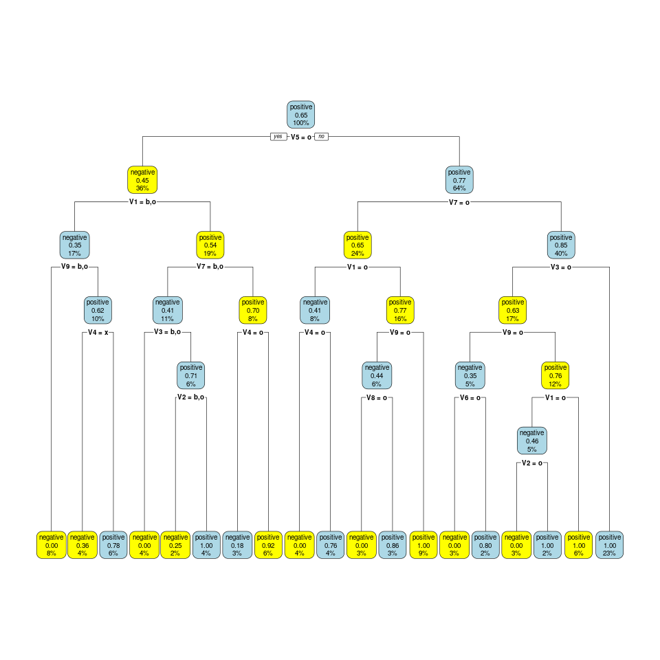

```r
rpart.plot(tree,box.col = c('lightblue','yellow'))
```

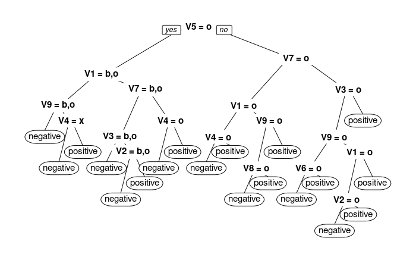

```r
prp(tree)
```

Interpretation: We can that if V5 != 0 and V7 != 0 and V3 != 0 then the tree will predict the output as positive. ( Example of one leaf decision rule)

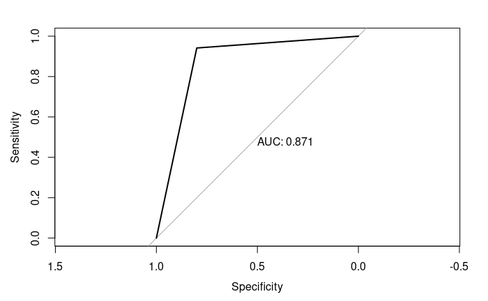

```r
library(pROC)
change = function(x){
  if(x == 'positive'){
    1
  }else{
    0
  }
}


test_probs = sapply(tree.preds$final_class, change)
df.test$V10 = sapply(df.test$V10, change)
test_roc = roc(df.test$V10 ~test_probs, plot = TRUE, print.auc = TRUE)
```

# Interpretation:

we can see that the auc is 0.871. where 1 represents the perfect classifier and 0.5 represents worthless classifier. So, there is a 87.1 % chance that the model will be able to distinguish between positive and negative class. ie. whether the v10 is positive or negative. ============================================================================================================================================